# Clusters of municipal water profiles

Clusters group municipality x zone x year rows (2016-2023) by profile features only (IRCA, coverage, rurality, altitude, rainfall, poverty, fiscal and performance indices). IRCA is utility-supplied (“prestadores”) IRCA from INS open data. Outcomes were not used.

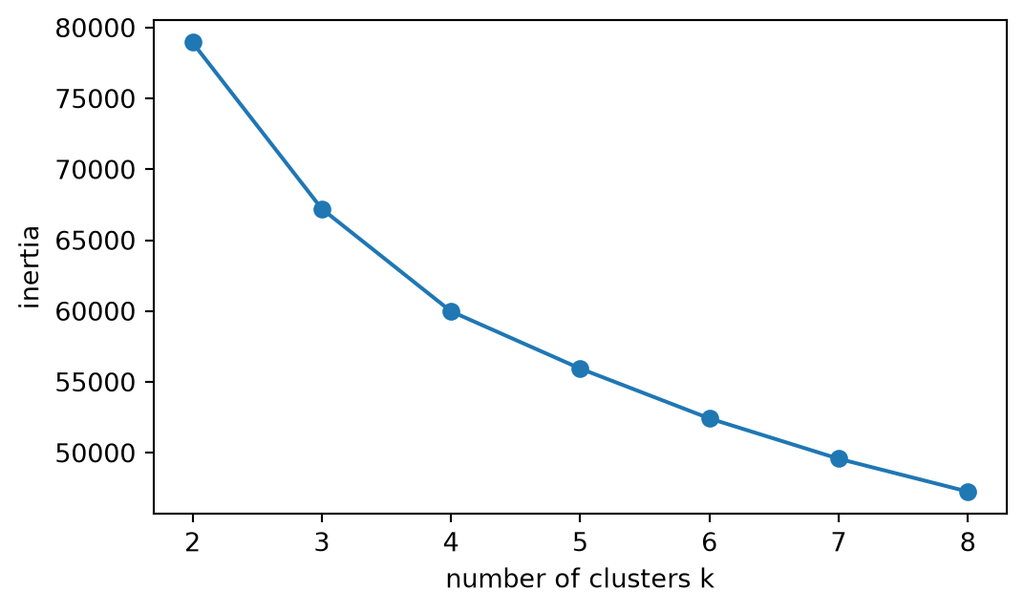

Figure 1: Elbow plot: k-means inertia for k = 2 to 8. The curve flattens after k = 4.

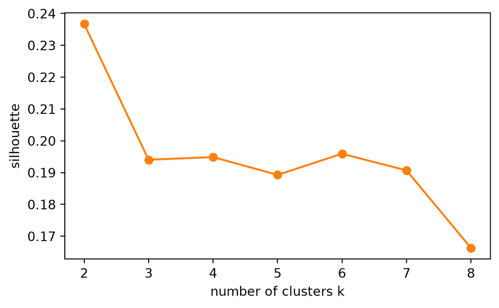

Figure 2: Mean silhouette score by k. Higher means better-separated clusters; all values are modest (below 0.25).

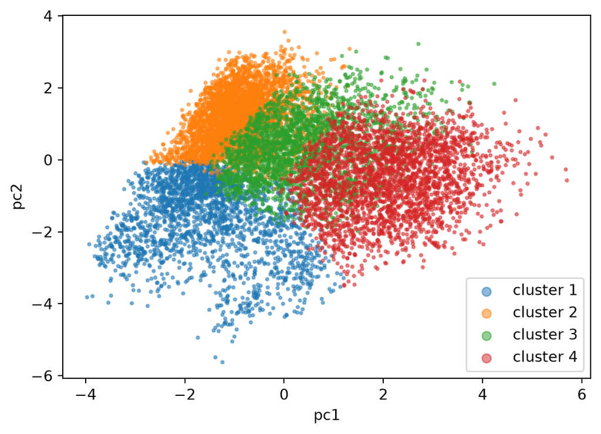

Figure 3: First two principal components of the standardised profile features, coloured by cluster. Descriptive grouping only.

## What sets each cluster apart?

Cells are each cluster’s mean z-score (standardised within year) per profile feature. Blue is below the yearly average and red above. Descriptive only.

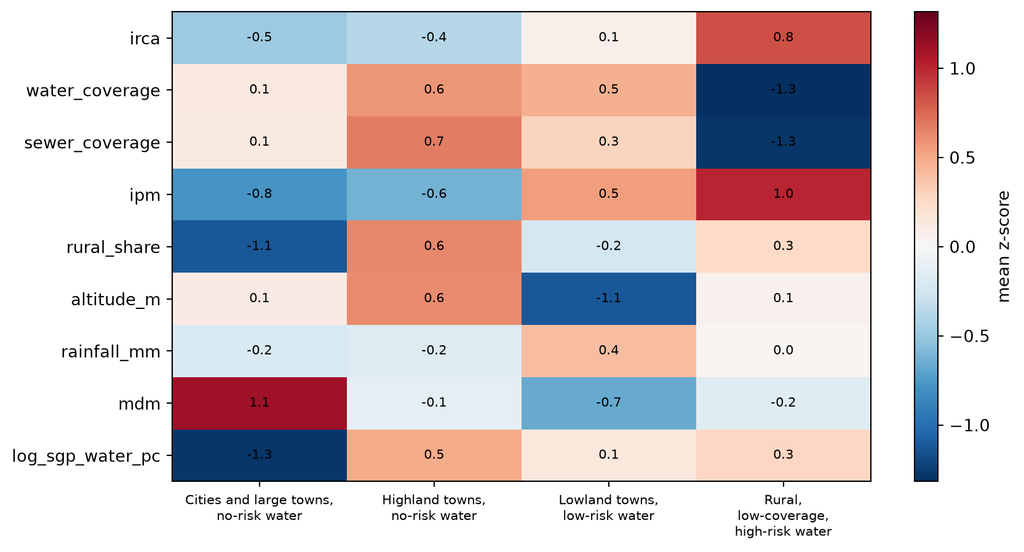

Figure 4: Cluster mean z-scores (within year) of the nine profile features; blue below average, red above.

## Outcomes by cluster (descriptive, not used for clustering)

Median per cluster and year; gaps are years the source does not cover (not joined). Infant mortality changes method in 2017 and Saber 11 has no 2018 or 2021 data.

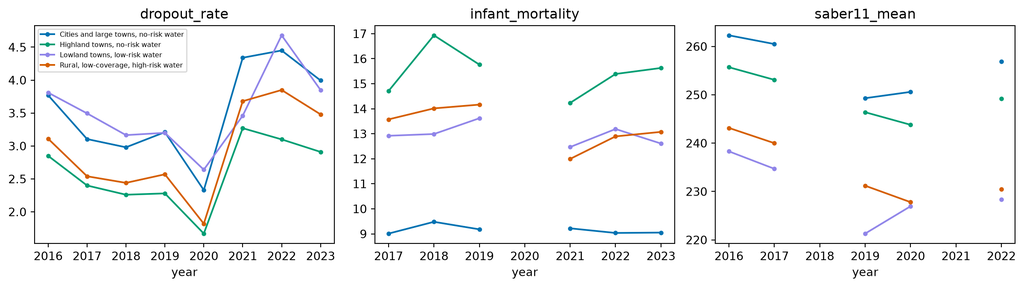

Figure 5: Median infant mortality, Saber 11 mean score and school dropout by cluster and year. Lines break in years without data. Association only; no causal claim.

## Worse water, more infant deaths? A within-cluster check

Median infant mortality (deaths per 1,000 live births) by IRCA band (utility-supplied, INS open data) within each cluster, with Spearman rho between IRCA and infant mortality and the number of rows `n` behind it. Only rows with an infant-mortality value count.

```
Median infant mortality by IRCA band:
```

```
Rows (n) behind each cell:
```

Table 1: Spearman rho (IRCA vs infant mortality) and n by cluster, and median infant mortality by IRCA band.

| cluster | spearman_rho | n | municipalities |
| --- | --- | --- | --- |
| Cities and large towns, no-risk water | -0.04 | 1035 | 270 |
| Highland towns, no-risk water | 0.10 | 1355 | 475 |
| Lowland towns, low-risk water | 0.05 | 1482 | 425 |
| Rural, low-coverage, high-risk water | 0.01 | 1290 | 570 |

| irca_band | Cities and large towns, no-risk water | Highland towns, no-risk water | Lowland towns, low-risk water | Rural, low-coverage, high-risk water |
| --- | --- | --- | --- | --- |
| No risk | 9.3 | 15.0 | 12.4 | 13.1 |
| Low | 8.8 | 16.0 | 13.1 | 13.7 |
| Medium | 9.4 | 17.2 | 13.2 | 12.0 |
| High | 8.3 | 15.9 | 12.9 | 13.6 |
| Unfit | NaN | 16.1 | 15.5 | 13.2 |

| irca_band | Cities and large towns, no-risk water | Highland towns, no-risk water | Lowland towns, low-risk water | Rural, low-coverage, high-risk water |
| --- | --- | --- | --- | --- |
| No risk | 708.0 | 801.0 | 589.0 | 254.0 |
| Low | 205.0 | 314.0 | 269.0 | 156.0 |
| Medium | 106.0 | 190.0 | 330.0 | 197.0 |
| High | 16.0 | 45.0 | 256.0 | 530.0 |
| Unfit | NaN | 5.0 | 38.0 | 153.0 |

**This is descriptive and does not establish a causal effect of water safety on infant mortality.** Within clusters the correlations are weak, and confounders (poverty, health services, altitude, rurality, the 2017 change in how infant mortality is measured) are not controlled for.